# Methods and Motivation

73-423 Forecasting for Economics and Business

## Building a Forecast

- Given series $\mathcal{Y}_T:=\{Y_t\}_{t=1}^T$
- Forecast **horizon** $h$
  - Number of periods out we want to forecast
- Goal: predict the value of $y_{T+h}$
- A **forecasting method** is a function that takes as input data $\mathcal{Y}_T$ and possibly other inputs, and produces a forecast
  $$\widehat{y}_{t+h}=f(\mathcal{Y}_T,\text{other stuff})$$
- Today
  - Overview of some example methods
  - How to evaluate results

## Simple Forecast Methods

- **Trivial**: always predict 0, regardless of the data
  $$f(\mathcal{Y}_T)=0$$
  - Simple, easy to compute, stable
- **Naïve**: Just pick the last value
  $$f(\mathcal{Y}_T)=y_T$$
  - The next period will be the same as the current period
  - Simple and straightforward, and uses the data
  - Also called “**random walk forecast**”
- **Mean**: Take the average past value
  $$f(\mathcal{Y}_T)=\frac{1}{T}\sum_{t=1}^T y_t$$
  - Still fairly simple, now uses all the data

## Implementation

- Apply methods to a monthly series of a Manufacturer’s inventories of Condensed Milk, 1971-1980
- Typical company forecasting task: predict inventories to avoid over-accumulation or stock-outs

```r
library(fpp2) #Loads forecasting functionsm and data sets
#Forecast using each of above methods
milknaive<-naive(condmilk,h=12) #Naive forecast, 12 months out
milkmean<-meanf(condmilk,h=12) #Mean forecast, 12 months out
trivialFC<-c(0,0,0,0,0,0,0,0,0,0,0,0)
milktrivial<-ts(trivialFC,start=c(1981,1),frequency=12) #Trivial forecast, 12 months out
```

## Plot

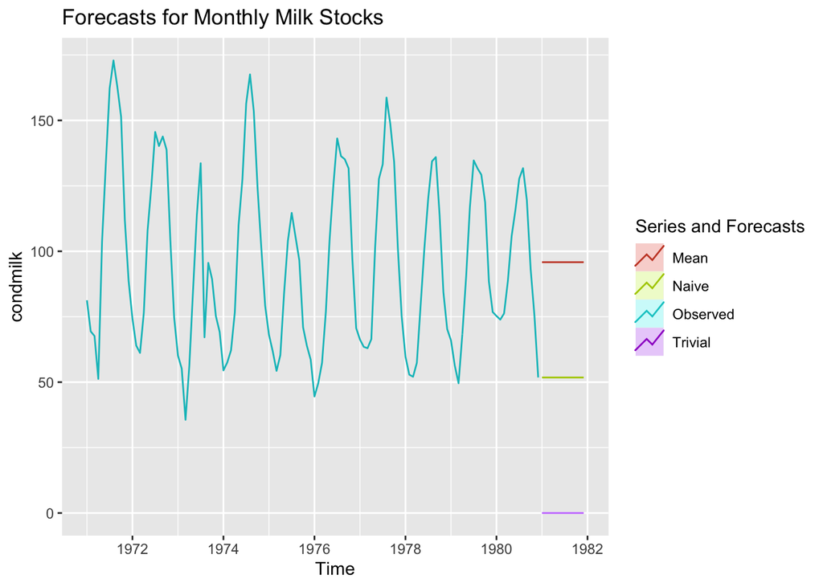

```r
#Plot the forecasts
autoplot(condmilk,series="Observed")+
  autolayer(milknaive, PI=FALSE, series="Naive")+
  autolayer(milktrivial, series="Trivial")+
  autolayer(milkmean, PI=FALSE,series="Mean")+
  ggtitle("Forecasts for Monthly Milk Stocks") +
  guides(colour=guide_legend(title="Series and Forecasts"))
```

## Methods with parameters

- Going beyond the simplest methods, one can construct families of methods which are similar
  - Differ by one or more additional inputs to the method, which must be chosen
  - Extra inputs are called **parameters**
  - Once parameters are set, method again depends only on the data
- Denote parameter by $\theta$, and set of possible parameters as $\Theta$
- A parametric forecast method is a set of methods

$$\{f(\mathcal{Y}_T,\theta,\text{other stuff})\}_{\theta\in\Theta}$$

## Examples of Parametric Methods

- **Trivial**: always predict the same number, $\theta$, regardless of the data
  $$f(\mathcal{Y}_T,\theta)=\theta$$
  - $\theta=0$ gives the trivial forecast
- **Autoregression**: Take $\theta$ times the last value
  $$f(\mathcal{Y}_T,\theta)=\theta y_T$$
  - $\theta=1$ gives the naïve forecast
  - Extend to horizon $h$ by $\widehat{y}_{T+h}=\theta^h y_T$
- **Weighted Average**: Take average of past value + a constant, with different weights on different times
  $$f(\mathcal{Y}_T,\{\theta_t\}_{t=1}^{T})=\theta_0+\sum_{t=1}^T \theta_t y_t$$
  - Extremely flexible, but requires many choices
    - Picking $\theta_t=\frac{1}{T}$ for all t, $\theta_0=0$ gives unweighted average
    - Picking $\theta_T=\theta$, $\theta_t=0$ for all $t<T$ gives autoregression

## Choosing parameters

- Applying a parametric method requires a choice of which parameters to use
- Can pick based on sensible default values
  - Random walk $\theta=1$ often a good choice for autoregression with economic data
- Usually apply a parameter selection method based on the data
  $$\theta=\widehat{\theta}(\mathcal{Y}_T)$$
- Full forecasting method now a function of data again
  $$f(\mathcal{Y}_T)=f(\mathcal{Y}_T,\widehat{\theta}(\mathcal{Y}_T))$$
- Many types of parameter selection methods exist
  - Will discuss details in later classes
- Selecting parameters not quite the same as “estimation” in statistics
  - Care about $f(\mathcal{Y}_T)$, not $\theta$ itself

## Implementation

- Forecast using parametric methods, with default parameter selection rules
  - Autoregressive models of order 1 and order 4
  - Simple Exponential Smoothing

```r
milkAR1selection<-Arima(condmilk,order=c(1,0,0),include.mean=FALSE) #Choose parameter of AR(1) model
    #Do not include added constant
milkAR1<-forecast(milkAR1selection,h=12) #Autoregression of order 1 forecast, 12 months out
milkAR4selection<-Arima(condmilk,order=c(4,0,0)) #Choose parameters of AR(4) model, including constant
milkAR4<-forecast(milkAR4selection,h=12) #Autoregression of order 4 forecast, 12 months out
milkexpsm<-ses(condmilk,h=12) #Simple Exponential Smoothing Forecast, 12 months out
```

## Plot

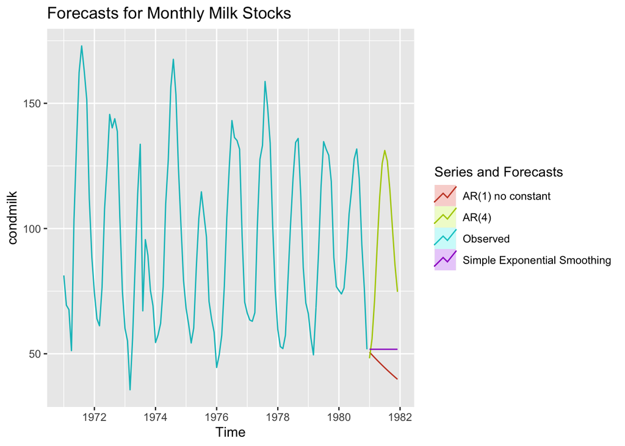

```r
#Plot the forecasts
autoplot(condmilk,series="Observed")+
  autolayer(milkAR1, PI=FALSE, series="AR(1) no constant")+
  autolayer(milkAR4, PI=FALSE,series="AR(4)")+
  autolayer(milkexpsm, PI=FALSE,series="Simple Exponential Smoothing")+
  ggtitle("Forecasts for Monthly Milk Stocks") +
  guides(colour=guide_legend(title="Series and Forecasts"))
```

## Parameters Chosen

```r
# alpha and l_0 from exponential smoothing
milkexpsm$model$fit$par
```

```
## [1]  0.99990 81.29198
```

```r
# AR(1) Coefficient
milkAR1selection$coef
```

```
##       ar1
## 0.9783295
```

```r
# AR(4) Coefficients
milkAR4selection$coef
```

```
##         ar1         ar2         ar3         ar4   intercept
##  0.98568158 -0.09175605 -0.11115186 -0.27093352 95.99392283
```

## Seasonal and trending data

- Some simple methods are designed to rely on and exploit particular features of existing data
- These methods extrapolate features like seasonality or trends to future data
- Let $m$ be the frequency of the series
  - ex: $m=4$ for quarterly, $m=12$ for monthly data
- **Seasonal naïve** forecast for seasonal data
  - Predict the value as the last observed value from the same season
    $$f(\mathcal{Y}_T)=y_{T+1-m}$$
  - Extend to horizon $h$ as $\widehat{y}_{T+h}=y_{T+h-m(\lfloor\frac{h-1}{m}\rfloor+1)}$
- **Drift Method** for trending data
  - Adds average growth to naïve forecast

$$f(\mathcal{Y}_T)=y_{T}+\frac{1}{T-1}\sum_{t=2}^{T}(y_t-y_{t-1})$$

- Seasonal and trending versions exist for autoregression, exponential smoothing, etc

## Implementation

- Forecast using seasonal and drift methods
  - Series appears highly seasonal, with minimal trend
  - So expect better results from seasonal method

```r
milksnaive<-snaive(condmilk,h=12) #Seasonal Naive forecast, 12 months out
milkdrift<-rwf(condmilk,drift=TRUE,h=12) #Drift forecast, 12 months out
```

## Plot

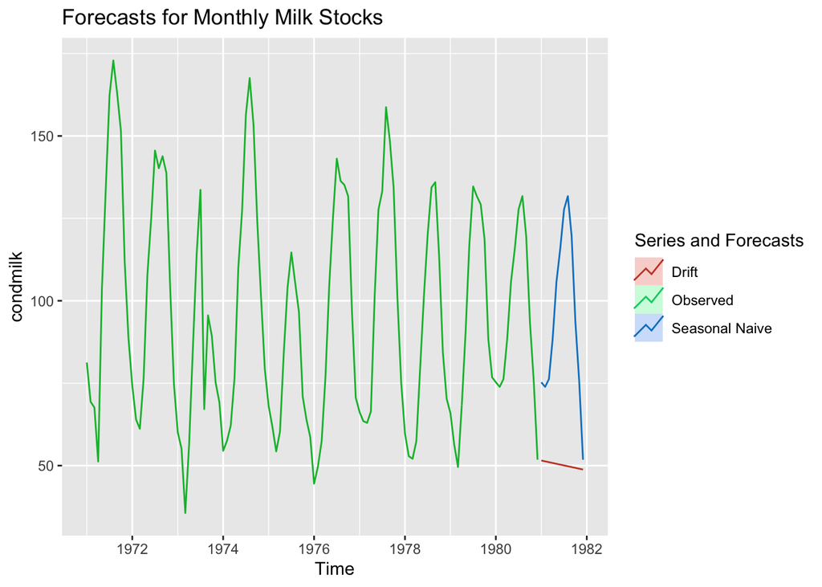

```r
#Plot the forecasts
autoplot(condmilk,series="Observed")+
  autolayer(milksnaive, PI=FALSE, series="Seasonal Naive")+
  autolayer(milkdrift, PI=FALSE,series="Drift")+
  ggtitle("Forecasts for Monthly Milk Stocks") +
  guides(colour=guide_legend(title="Series and Forecasts"))
```

## Adding External Data

- A forecast might be a function of series of interest AND other data, $\mathcal{X}_T$
  - Related time series, Background information, etc
- Method becomes
  $$\widehat{y}_{T+h}=f(\mathcal{Y}_T,\mathcal{X}_T,\text{other stuff})$$
- Example: **(Predictive) Regression**
  - Forecast is linear function of $x_T$
    $$\widehat{y}_{T+h}=f(\mathcal{Y}_T,\mathcal{X}_T,\theta)=\theta_0+\theta_1 x_T$$
- More generally, may use subjective or **judgmental** assessment to come up with a number
- **Judgmental forecast**: think real hard and come up with a number
  $$\widehat{y}_{T+h}=f(\mathcal{Y}_T,\text{whatever you're thinking})=???$$
- **Expert forecast**: ask someone else to think real hard and come up with a number
  $$\widehat{y}_{T+h}=f(\mathcal{Y}_T,\text{whatever they're thinking})=???$$

## Random methods

- Some forecasting methods involve randomness
- Let $U$ be a random variable, with distribution $F(u)$
- A randomized method takes the random variable as an input, so its output is also random
- E.g. **Random Guess**: pick a number at random, without using the data
  $$f(\mathcal{Y}_T,U)=U$$
  - A random guess is a random generalization of trivial method
  - A randomized version of any other procedure can be made by adding $U$ to the output
- Not super common, but one part of some more complicated methods

## Exercise: Try it yourself

- Go to [Kaggle link](https://www.kaggle.com/davidchilders/forecast-methods) to try methods on Electricity Price data
- Copy and edit file to implement, then share with instructor.

## Choices: Finding a “Good” method

- Now we know we CAN use any of these methods to forecast
- What SHOULD we use?
  - Depends on application
- Want a good guess because bad guesses will lead to bad decisions
  - Sales forecasts too high or low both lead to incorrect inventory decisions, lower profit
  - Financial market forecasts too high or low lead to bad buy/sell decisions, lower profit
  - Missed economic indicator forecasts can lead to inappropriate policy, worse outcomes
- Ideal forecast: exact true value $y_{T+h}$
  - Problem: value isn’t known
- Next best choice: something very close to $y_{T+h}$
  - Problem: also not known
  - Problem: what is *close*?
- Need a measure of how bad decision will have turned out to be given an incorrect forecast
  - A “Loss Function”

## Loss Functions

- Mathematically, a loss function $\ell(.,.)$ $\mathrm{Y}\times\mathrm{Y}\to\mathbb{R}$
  - Takes true value $y$ and forecast value $\widehat{y}$
  - Outputs a number measuring how bad the guess was
- *After* truth is known, says how bad forecast was
- Acts like (dis)utility of outcome
  - If used to utility functions from economics, this is negative of utility
- Usual property
  - $y=\underset{\widehat{y}}{\arg\min}\ell(y,.)$ for all $y$
  - A perfect forecast is alway (weakly) better than other guesses
- If above holds, can use normalized version
  - $\ell(y,y)=0$ for any $y$. 0 Loss for exactly correct guesses
  - $\ell(y_1,y_2)\geq 0$ for any $y_1,y_2$. Incorrect guesses are (weakly) worse
- If profit $\pi(y,\widehat{y})$ is maximized by correct forecasts
  - $\ell(y,\widehat{y})=\pi(y,y)-\pi(y,\widehat{y})$ is equivalent loss function

## Examples

- Common loss functions $\ell(y,\widehat{y})$ use measures of absolute or relative distance
- Absolute Error
  $$|y-\widehat{y}|$$
- Squared Error
  $$(y-\widehat{y})^2$$
- Absolute Percent Error: Requires non-zero values of $y$
  $$\left|100\frac{(y-\widehat{y})}{y}\right|$$
- Absolute Scaled Error: Compares error to average error of a random walk forecast
  $$\left|\frac{(y-\widehat{y})}{\frac{1}{T-1}\sum_{t=2}^T|y_t-y_{t-1}|}\right|$$

## Evaluating Loss

- To see how forecast method performed in past, can evaluate loss within data $\mathcal{Y}_T$
- Sample mean of loss function common way to describe past performance
  $$\frac{1}{T-h}\sum_{t=1}^{T-h}\ell(y_{t+h},f(\mathcal{Y}_{t}))$$
- For Squared Error, this is called MSE: Mean Squared Error
  - Usually take square root of MSE to get RMSE: Units same as series
  - For Absolute Error, MAE
  - For Abolute Percent Error, MAPE
  - For Absolute Scaled Error, MASE
- Answers question: “How much loss would I have incurred (on average) had I used this method in the past?”
- *Not* same as “How much loss will I incur if I use this method in the future?”

## Evaluating Parametric Methods

- With parameterized methods, common to use different data for forecast rule and parameter selection rule
  $$\widehat{y}_{t+h}=f(\mathcal{Y}_t,\widehat{\theta}(\mathcal{Y}_T))$$
- Predicted value for $y_{t+h}$ that you would predict at $t$ using the forecast rule chosen using all the data up to $T$
  - Mostly done for computational reasons: methods to calculate $\widehat{\theta}(\mathcal{Y}_T)$ can be very slow
- Values $y_{t+h}-f(\mathcal{Y}_t,\widehat{\theta}(\mathcal{Y}_T))$ are called **residuals**
  - $\frac{1}{T-h}\sum_{t=1}^{T-h}\ell(y_{t+h},f(\mathcal{Y}_t,\widehat{\theta}(\mathcal{Y}_T)))$ is residual error
  - Also given name MSE, MAE, MAPE, etc
- Residuals are a measure of error, but do not describe loss from a feasible procedure
- To compare a feasible measure, also use only past data for forecasting rule
  - Predict $\widehat{y}_{t+h}=f(\mathcal{Y}_t,\widehat{\theta}(\mathcal{Y}_t))$
  - Errors and loss from this approach called “evaluation on rolling forecast origin”
  - Calculate via **tsCV** in forecast package
  - Can be slow: calculate $\widehat{\theta}(\mathcal{Y}_t)$ many times

## Evaluation

- Construct rolling forecast origin AR4 models and evaluate 1-month errors

```r
far4 <- function(x, h){forecast(Arima(x, order=c(4,0,0)), h=h)}
AR4forecasterrors<-tsCV(condmilk,far4,h=1)
#Rolling Forecast Error RMSE and MAE
RMSEfc<-sqrt(mean((AR4forecasterrors)^2,na.rm = TRUE))
MAEfc<-mean(abs(AR4forecasterrors),na.rm = TRUE)
#Compare RMSE and MAE on residuals
RMSEres<-sqrt(mean((milkAR4selection$residuals)^2,na.rm = TRUE))
MAEres<-mean(abs(milkAR4selection$residuals),na.rm = TRUE)
```

```r
library(knitr)
library(kableExtra)
mse_tbl <- data.frame(Method = c("Residual", "Rolling"),RMSE = c(RMSEres, RMSEfc), MAE = c(MAEres, MAEfc))

kable(mse_tbl) %>%
  kable_styling(full_width = F) %>%
  column_spec(1,border_right = T)
```

| Method | RMSE | MAE |
| --- | --- | --- |
| Residual | 12.73835 | 8.905466 |
| Rolling | 15.42559 | 10.235622 |

- Rolling window errors are larger than residual errors
- Rolling errors reflect what you *would have* gotten from running method in the past

## Train vs Test Set

- Simple compromise: Split $\mathcal{Y}_T$ into
  $$\mathcal{Y}_{Train},\mathcal{Y}_{Test}$$
  $$\mathcal{Y}_{Train}=\{y_t\}_{t=1}^{S},\mathcal{Y}_{Test}=\{y_t\}_{t=S+1}^{T}$$
  - where $S$ is split point
- Compute error as
  $$\frac{1}{T-S}\sum_{t=S+1}^{T}\ell(y_{t},f(\mathcal{Y}_{t-h},\widehat{\theta}(\mathcal{Y}_{Train})))$$
- Allows fast computation: compute $\widehat{\theta}(\mathcal{Y}_{Train})$ only once
- Performance measure describes feasible method, since test set not used to select $\theta$

## Train vs Test Set

- Compute test set accuracy for milk forecasts by AR(4)

```r
milktrain<-window(condmilk,end=c(1977,12)) #Until 1978
milktest<-window(condmilk,start=c(1978,1)) #After 1978
milkAR4train<-Arima(milktrain,order=c(4,0,0))
```

```r
#Constructing forecast on test data requires some ugly code: hidden
S<-length(milktrain)           #Length of training data series
testlength<-length(milktest)   #Length of test data series
p<-4 #Number of lags used in autoregression
#Arima library reports mean rather than constant term in our notation
#So need to transform results to get numbers in formula on slide 8
theta0<-(1-sum(milkAR4train$coef[1:p]))*milkAR4train$coef[p+1]
milkAR4testpred<-c() #Make list of forecasts
#Use selected parameters to construct forecast
for(t in 1:testlength){
  milkAR4testpred[t]<-milkAR4train$coef[p:1]%*%condmilk[(S-p+t):(S+t-1)]+theta0
}
milkAR4testforecasts<-ts(milkAR4testpred,start=c(1978,1),frequency=12) #Convert to time series
```

- Construct predictions and evaluate performance on test set

```r
#Test set RMSE and MAE
RMSE<-sqrt(mean((milkAR4testforecasts-milktest)^2))
MAE<-mean(abs(milkAR4testforecasts-milktest))
```

```r
err_tbl <- data.frame(Method = c("Test Set Error"),RMSE = c(RMSE), MAE = c(MAE))

kable(err_tbl) %>%
  kable_styling(full_width = F) %>%
  column_spec(1,border_right = T)
```

| Method | RMSE | MAE |
| --- | --- | --- |
| Test Set Error | 7.602968 | 5.952242 |

## Plot

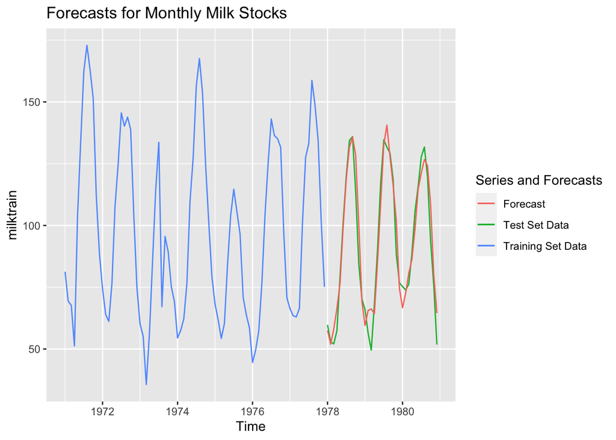

```r
#Plot results
autoplot(milktrain, series="Training Set Data")+
  autolayer(milktest,series="Test Set Data")+
  autolayer(milkAR4testforecasts,series="Forecast")+
  ggtitle("Forecasts for Monthly Milk Stocks") +
  guides(colour=guide_legend(title="Series and Forecasts"))
```

## The problem of induction

- Now that we can measure forecasting performance, what do we know about how to forecast?
  - Not much!
- Problem:
- “Past performance does not necessarily predict future results”
  - U.S. Securities and Exchange Commission mandatory warning, paraphrasing Scottish Enlightenment philosopher David Hume

[figure not shown]

David Hume. Source: Wikimedia

## The problem of induction

- No matter how good the empirical performance of the method, or how much data, cannot say anything at all about what will happen on new data without additional logical premises
- Will sun rise tomorrow?
  - Has done so every recorded day in the past
  - Premise that things that have always happened before will continue to happen might be true
  - But can’t be justified by the fact that it’s been true in the past
- Circularity of reasoning best expressed by considering opposite belief (cf Aaronson (2013) p229)
- There is “a planet full of people who believe in *anti-induction*: if the sun has risen every day in the past, then today, we should expect that it won’t. As a result, these people are all starving and living in poverty. Someone visits the planet and tells them,”Hey, why are you still using this anti-induction philosophy? You’re living in horrible poverty."
  - They respond; “Well, it never worked before…”
- Clearly, we are going to need some additional principles

## Next topic

- Principles of forecasting
  - No “right” answer
  - Multiple reasonable approaches